# PSY 8712 Week 8 Project

Lisette Horne

2024-03-17

# **Reproducible Image and Online Resources**

An image of this project as of *2024-03-17* can be accessed by [clicking this link](https://mybinder.org/v2/gh/lisette-18/psy8712-week8/HEAD)

An interactive web app is available by [clicking this link instead](https://lisette-18.shinyapps.io/shiny_week8/)

# **Script Settings and Resources**

```r
setwd(dirname(rstudioapi::getActiveDocumentContext()$path))
library(rsconnect)
library(tidyverse)
```

# **Data Import and Cleaning**

In the following chunk, the dataset is imported and cleaned for analysis. timeStart is converted to a POSIXct (i.e., the appropriate format for time), gender and condition are converted to factors with their respective levels and labels (i.e., will allow us to develop our graphs), question 5 is reverse coded, and the mean across rows for Q1-Q6, and the mean across rows Q8-10 are calculated (i.e., all which allows us to analyze the data in the following sections).

```r
week8_tbl <- read_csv("../data/week3.csv") %>%
  mutate(timeStart = ymd_hms(timeStart)) %>%
  mutate(condition = factor(condition, levels = c("A","B","C"), labels = c("Block A", "Block B", "Contol"))) %>%
  mutate(gender = factor(gender, levels = c("M", "F"), labels = c("Male", "Female"))) %>%
  mutate(q5 = 6-q5) %>%
  mutate(mean1_6 = rowMeans(across(q1:q6)),
         mean8_10 = rowMeans(across(q8:q10)))
```

# **Visualization**

In the following chunk, display paginated data from Q1-Q6 and display a scatterplot between mean scores of Q1 - Q6 and mean scores of Q8 - Q10. Updated YAML header to display paginated data, used select to choose the columns included using paste0 (so the syntax is reproducible if other columns were to be added) and ggplot with geom_point (i.e., allows for the creation of the scatterplot with appropriate x and y labs, as well as the OLS regression line).

| q1 | q2 | q3 | q4 | q5 | q6 |
| --- | --- | --- | --- | --- | --- |
| 5 | 4 | 4 | 1 | 2 | 1 |
| 2 | 4 | 3 | 1 | 3 | 1 |
| 5 | 5 | 2 | 1 | 5 | 1 |
| 4 | 3 | 4 | 2 | 4 | 1 |
| 3 | 1 | 3 | 5 | 2 | 1 |
| 4 | 3 | 2 | 3 | 3 | 1 |
| 2 | 4 | 1 | 3 | 1 | 1 |
| 4 | 2 | 5 | 1 | 1 | 1 |
| 2 | 5 | 3 | 4 | 2 | 1 |
| 3 | 4 | 2 | 4 | 5 | 1 |

[output cut: 39 more lines]

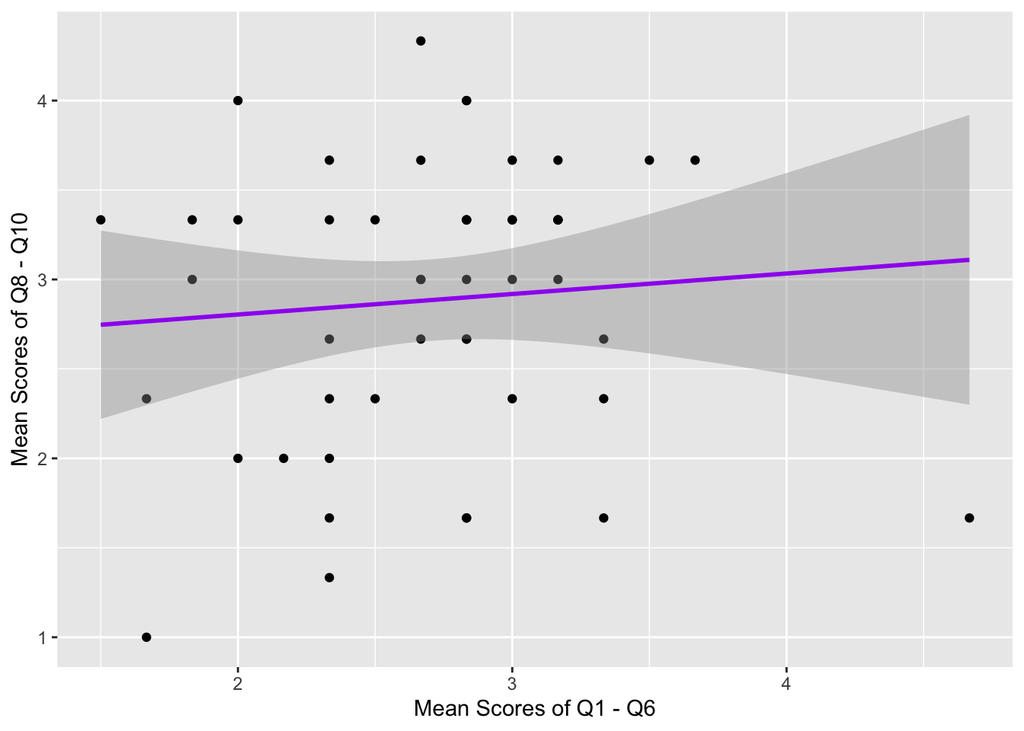

# **Analysis**

In the following chunk, a display of the correlation between the two mean scores and asssociated p-value is shown. cor.test() is used given that it will perform a hypothesis test between two variables and their correlation coefficient.

```
##
##  Pearson's product-moment correlation
##
## data:  week8_tbl$mean1_6 and week8_tbl$mean8_10
## t = 0.58309, df = 47, p-value = 0.5626
## alternative hypothesis: true correlation is not equal to 0
## 95 percent confidence interval:
##  -0.2012466  0.3574248
## sample estimates:
##        cor
## 0.08474575
```

I observed a correlation of .08. Based on the provided p-value (0.56), I can assume we are using the standard .05 for a cutoff. This then indicates that the results are not statistically significant so there is no significant correlation between the two means.

# **Data Export**

In the following chunk, a smaller version of the dataset is created for use with the shiny app development. The following variables were selected based on the desired display output for the app.

```r
week8_tbl %>%
 select(mean1_6, mean8_10, gender, timeEnd) %>%
  saveRDS("../shiny_week8/shiny_data.rds")
```